# Staff Forum

20 October 2020

What do we want with a redesign of the BPharm(Hons)?

## What is the purpose of the curriculum?

Train students to develop a pharmacist’s **imagination**:

To see the world in the distinctive way that pharmacists do.

To have the knowledge and skills to collaborate with others to improve health through wise use of medicines.

## Professional abstinence

Biggs, Hall, and Charrois (2019):

> We define professional abstinence as consciously choosing not to provide the full scope of patient care activities

## Our graduates need to:

- be **person centred** (the goals and values of the person that the pharmacist cares for needs to be at the centre of everything they do)
- have the **knowledge** and **skills** (competencies) to deliver safe and effective care, and
- be **socially accountable** for medicine-related outcomes (for individuals and the community)

## A content analysis of our intended curriculum (Noble et al. 2011)

Our learning objectives:

- tended to focus on drugs rather than people and
- the lower-levels of Blooms taxonomy (knowledge and understanding) rather than higher-levels (evaluate and create).

Our assessment focused on written exams, heavily weighted with multiple-choice questions.

## Our current curriculum

- Written exams are responsible for more than half of the BPharm(Hons): 54%
- Multiple-choice questions comprise 74% of the marks for these exams

## Longitudinal study of interns progressing into first year of practice (Judy Burrows 2016, 2020)

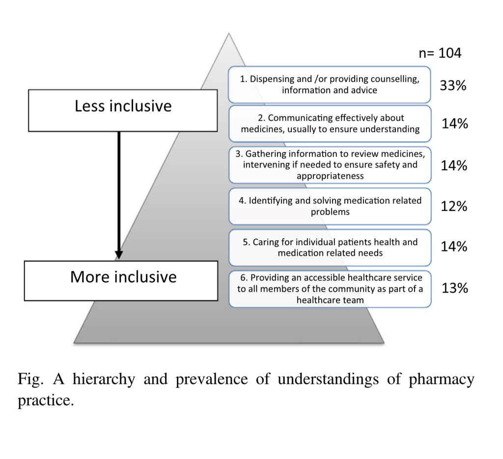

## Take away

Some students demonstrate an approach to practice that suggests our curriculum (in context) can achieve its aims

Many don’t (at least in the first year or two of practice)

*How can we bring more students along?*

## Can we better assess critical thinking, clinical reasoning and decision-making?

> Identify assessment in your course indented to assess “independence and creativity” and “critical judgement”.

> Does the assessment explicitly assess critical thinking and independent thought? Or does it assess “in-depth knowledge”?

## What is our strategy?

- The current curriculum takes a knowledge-first approach and hopes that some of the more complex aspects of practice come in later (critical thinking, person centered care)
- Let’s rethink this and look for a knowledge-reasoning-people-first approach from Y1

## How well do we deliver learning?

- Most students experience most of our courses online
- However: we continue to deliver the learning activities in a model purpose-built for face-to-face delivery

## There are opportunities in developing online resources

- Encourage inquiry-based learning through reusable recordings discussing threshold concepts and using quizzes and other automatic feedback methods to support active learning
- Provide opportunities for students to work through learning activities self-directed or in small asynchronous collaborative groups
- Shift ‘face-to-face’ discussion to application of concepts and troubleshooting

## Summary

The objective of the BPharm(Hons) program is to create decision-makers.

1. Review assessment types to better balance the assessment of critical thinking, evidence synthesis and problem solving with the current practices we have for knowledge assessment
2. Review the alignment of learning objectives with mode of delivery.

## Next questions…

- What are the opportunities in relation to experiential and work-integrated learning within the curriculum to achieve our goals?
- How do we ensure person centred care is at the core of the curriculum?
- What are the key threshold concepts that students need to have across the distinct scientific areas that inform the breadth of pharmacy practice?
- Which ‘facts’ do we cut in order to produce better well-rounded decision-makers?
- How do we prioritise, evaluate and recognise our activities to ensure that we can make concrete progress while appreciating our multiple commitments, and the resources we have available to us?
- …

## References

Biggs, Catherine, Jill Hall, and Theresa L. Charrois. 2019. “Professional abstinence: What does it mean for pharmacists?” *Canadian Pharmacists Journal / Revue Des Pharmaciens Du Canada* 153 (3): 148–50. https://doi.org/10.1177/1715163519840055.

Burrows, Judith, Gloria Dall’Alba, and Adam La Caze. 2016. “Becoming pharmacists: Students’ understanding of pharmacy practice at graduation from an Australian University.” *Currents in Pharmacy Teaching and Learning* 8: 729–41. https://doi.org/10.1016/j.cptl.2016.08.007.

———. 2020. “We are all patient-centred now, aren’t we? Lessons from new pharmacy graduates.” *Currents in Pharmacy Teaching and Learning* 12 (5): 508–16. https://doi.org/10.1016/j.cptl.2020.01.017.

Noble, Christy, Mia O’Brien, Ian Coombes, P Nicholas Shaw, and Lisa Nissen. 2011. “Concept mapping to evaluate an undergraduate pharmacy curriculum.” *American Journal of Pharmaceutical Education* 75 (3): 55. https://doi.org/10.5688/ajpe75355.